# Elections

Prajwal Vijendra

September 5, 2018

## Elections Problem Set

```r
library(tidyverse)
elections = read.csv("Elections.csv", header = T)

head(elections)
```

```
##   X   County Buchanan2000 Bush2000
## 1 1  Alachua          262    34062
## 2 2    Baker           73     5610
## 3 3      Bay          248    38637
## 4 4 Bradford           65     5413
## 5 5  Brevard          570   115185
## 6 6  Broward          789   177279
```

```r
summary(elections)
```

```
##        X             County    Buchanan2000       Bush2000
##  Min.   : 1.0   Alachua : 1   Min.   :   9.0   Min.   :  1316
##  1st Qu.:17.5   Baker   : 1   1st Qu.:  46.5   1st Qu.:  4746
##  Median :34.0   Bay     : 1   Median : 114.0   Median : 20196
##  Mean   :34.0   Bradford: 1   Mean   : 258.5   Mean   : 43356
##  3rd Qu.:50.5   Brevard : 1   3rd Qu.: 285.5   3rd Qu.: 56542
##  Max.   :67.0   Broward : 1   Max.   :3407.0   Max.   :289456
##                 (Other) :61
```

Lets create the scatter plot for County and Buchanan. We can see from the scatter plot that the value for Palm beach is an outlier.

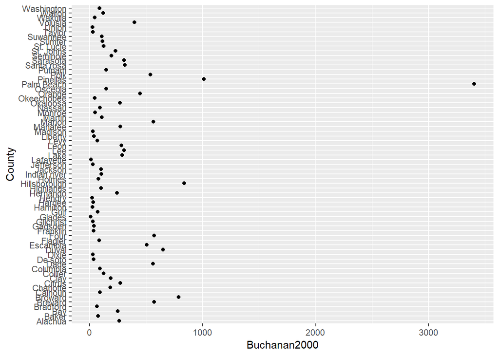

```r
ggplot(data = elections) + geom_point(mapping = aes(x =  Buchanan2000, y = County))
```

Lets create the scatter plot for Bush and Buchanan. We can see from here aswell that the value for Palm beach is an outlier.

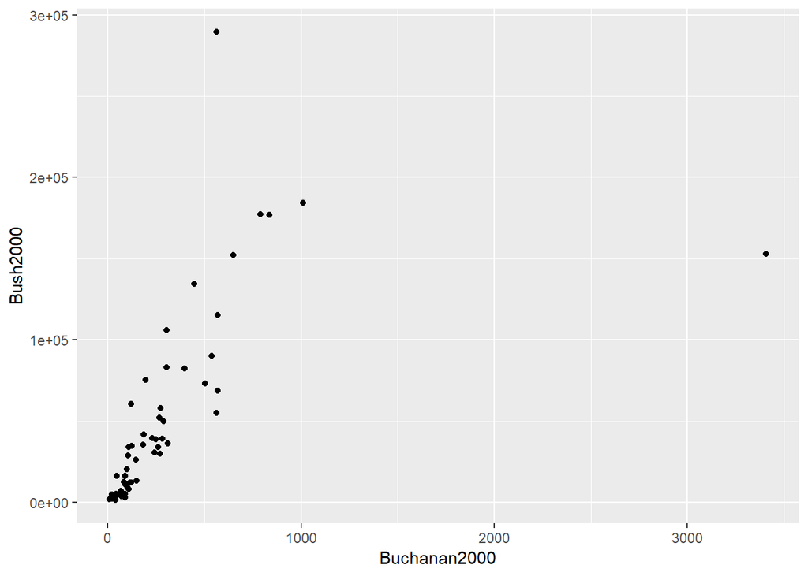

```r
ggplot(data = elections) + geom_point(mapping = aes(x =  Buchanan2000, y = Bush2000))
```

We can create a subset of the data by removing the outlier to create the linear regression model without the outlier.

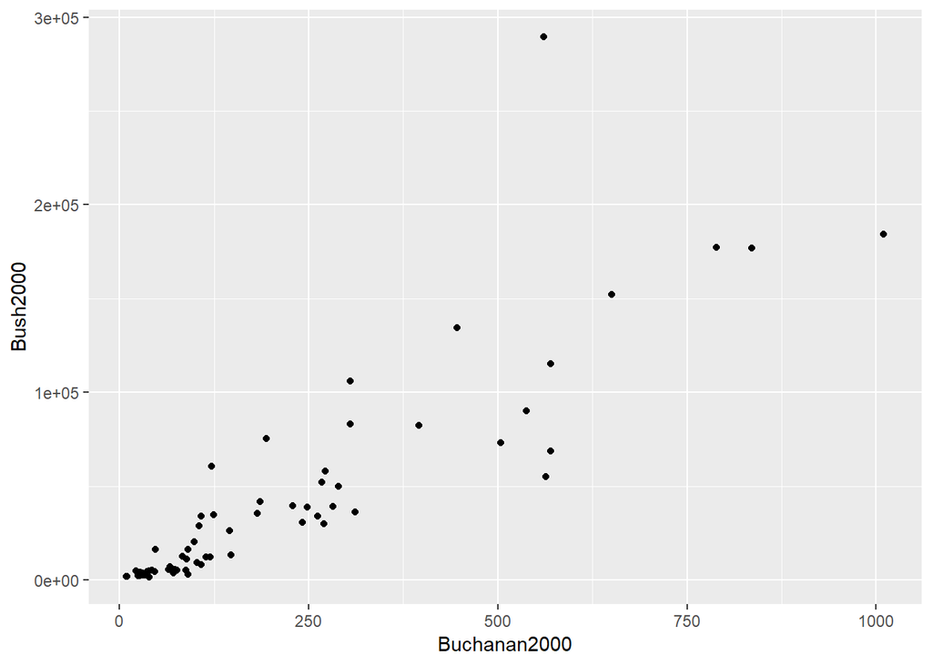

```r
elections2 = subset(elections, elections$County != 'Palm Beach')

ggplot(data = elections2) + geom_point(mapping = aes(x =  Buchanan2000, y = Bush2000))
```

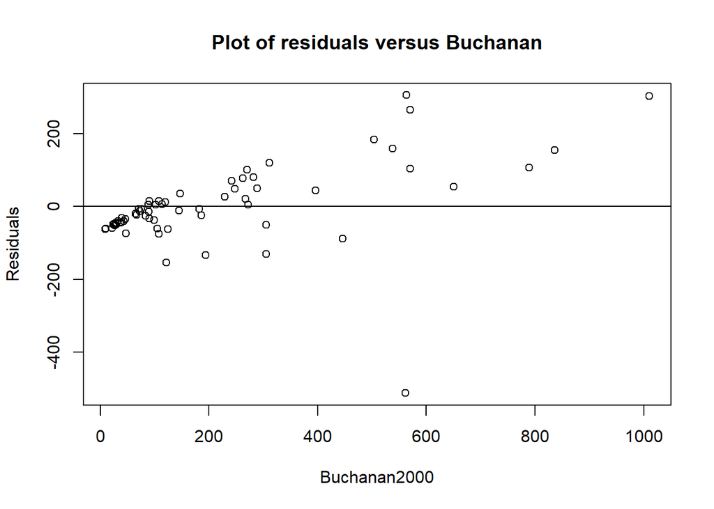

```r
election_model = lm(Buchanan2000 ~ Bush2000, data = elections2)

plot(y = election_model$residual, x=elections2$Buchanan2000, ylab = "Residuals", xlab = "Buchanan2000", main = "Plot of residuals versus Buchanan")
abline(0,0)
```

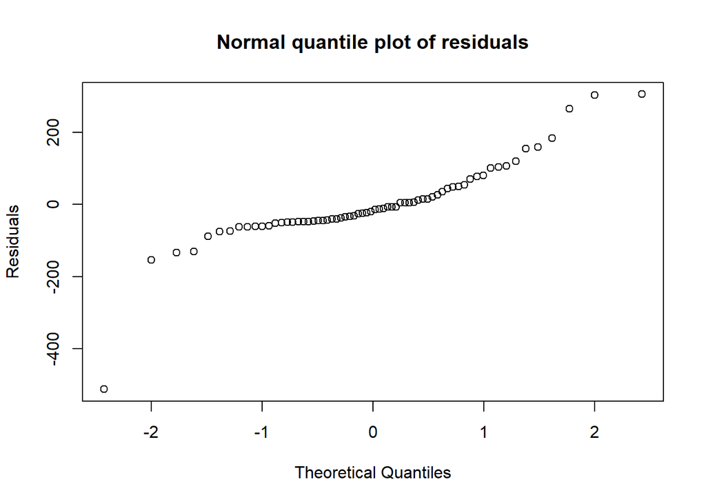

```r
qqnorm(election_model$residuals, ylab = "Residuals", main = "Normal quantile plot of residuals")
```

We can see from the scatter plot that the relationship between Bush and Buchanan is not perfectly linear. Also, plot of residual versus Buchanan does not exhibit constant variance. Looking at the qq plot, we can see that the plot does not exhitbit normal distribution.

We can take the log values of Bush and Buchnanan and try to see if these variable have a linear relationship.

```r
elections2$LogBuchanan2000 = log(elections2$Buchanan2000)

elections2$LogBush2000 = log(elections2$Bush2000)

election_model2 = lm(LogBuchanan2000 ~ LogBush2000, data = elections2)

summary(election_model2)
```

```
##
## Call:
## lm(formula = LogBuchanan2000 ~ LogBush2000, data = elections2)
##
## Residuals:
##      Min       1Q   Median       3Q      Max
## -0.95631 -0.21236  0.02503  0.28102  1.02056
##
## Coefficients:
##             Estimate Std. Error t value Pr(>|t|)
## (Intercept) -2.34149    0.35442  -6.607 9.07e-09 ***
## LogBush2000  0.73096    0.03597  20.323  < 2e-16 ***
## ---
## Signif. codes:  0 '***' 0.001 '**' 0.01 '*' 0.05 '.' 0.1 ' ' 1
##
## Residual standard error: 0.4198 on 64 degrees of freedom
## Multiple R-squared:  0.8658, Adjusted R-squared:  0.8637
## F-statistic:   413 on 1 and 64 DF,  p-value: < 2.2e-16
```

```r
confint(election_model2)
```

```
##                 2.5 %    97.5 %
## (Intercept) -3.049512 -1.633461
## LogBush2000  0.659109  0.802815
```

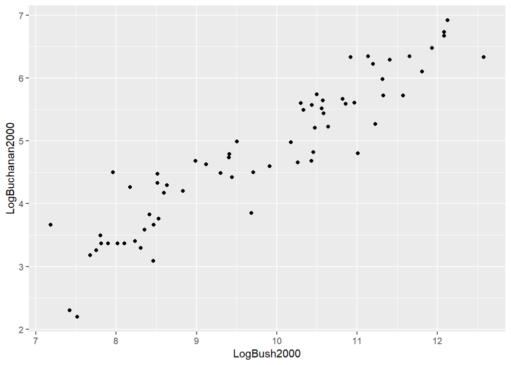

```r
ggplot(data = elections2) + geom_point(mapping = aes(x =  LogBush2000, y = LogBuchanan2000))
```

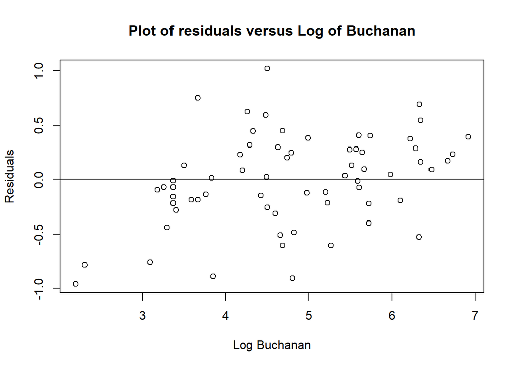

```r
plot(y = election_model2$residual, x=elections2$LogBuchanan2000, ylab = "Residuals", xlab = "Log Buchanan", main = "Plot of residuals versus Log of Buchanan")
abline(0,0)
```

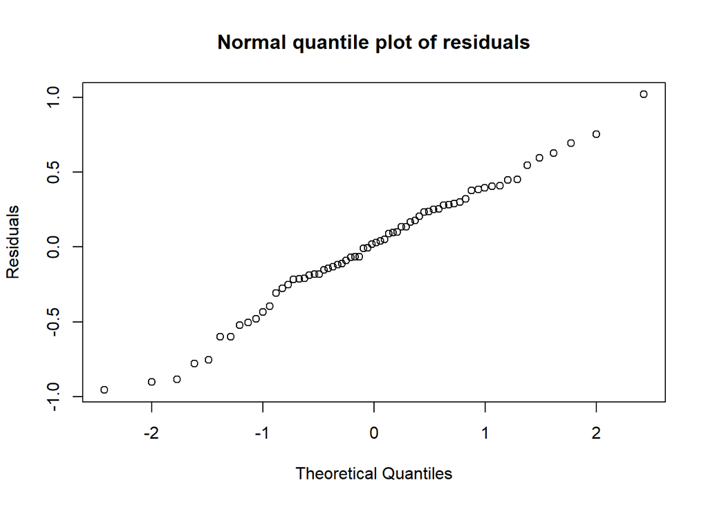

```r
qqnorm(election_model2$residuals, ylab = "Residuals", main = "Normal quantile plot of residuals")
```

We can see that Log of Bush and Log of Buchanan follows a linear relationship.

The Plot of residual and log of Buchanan exhibits constant variance.

The qq plot shows that the left most points does not fall on the line and hence creates the doubt if it satisfies the normal ditribution.

```r
bush = log(152846)

new.data = data.frame(LogBush2000 = bush)

exp(predict.lm(election_model2, new.data, interval = "prediction"))
```

```
##        fit      lwr      upr
## 1 592.3769 250.8001 1399.164
```

We can see that from the predicted value of Buchanan is 592.37 and the 95% perdiction interval lies between 250.8001 and 1399.164. However, the actual value in the dataset was 3407. This suggests that the butterfly layout ballot caused some of the votes to be accidently casted for Buchanan insteal of Gore.